# Introdução a Mapas no R

Nicholas A. C. Marino

nac.marino@gmail.com

github.com/nacmarino/introducaoR

# Elementos da Aula (baseada na aula da Dra. Andrea Sanchez Tapia/2016) + atualizações minhas

1. O que está aula é e o que ela não é!;
2. Utilizando o conteúdo do R para gerar mapas simples;
3. Criando mapas simples a partir de arquivos raster;
4. Usando informações da interação com a internet para criar mapas simples.

## O que está aula é e o que ela não é!

O R possui uma ampla capacidade e versatilidade para a execução de praticamente qualquer tarefa - inclusive para a criação e edição de mapas. É possível usar o R e toda a sua funcionalidade de forma muito similar àquela de programa como o ArcGIS. No entanto, este não será o nosso objetivo aqui, mas sim apresentar a funcionalidade mais básica possível do R para a criação de mapas (principalmente aqueles que sempre queremos adicionar em uma dissertação, tese ou manuscrito).

Existe uma diversidade enorme de material e sites na internet com material sobre a confecção de mapas no R. Sugiro dar uma olhada de forma mais detalhada no material gerado pela Dra. Andrea Sanchez Tapia para este mesmo curso em 2016 (`99_cursos_anteriores/09_Rmaps`) e/ou nos sites listados abaixo:

- R Special Interest Group on using Geographical data and Mapping: https://stat.ethz.ch/mailman/listinfo/r-sig-geo
- TaskView: Analysis of Spatial Data: https://cran.r-project.org/web/views/Spatial.html
- Lovelace, R., & Cheshire, J. (2014). Introduction to visualising spatial data in R. National Centre for Research Methods Working Papers, 14(03). Retrieved from https://github.com/Robinlovelace/Creating-maps-in-R
- Kahle & Wickham 2012 - ggmaps: https://dl.dropboxusercontent.com/u/24648660/ggmap%20useR%202012.pdf
- Kim Gilbert http://www.zoology.ubc.ca/~kgilbert/mysite/Miscellaneous_files/R_MakingMaps.pdf
- Kevin Johnson http://www.kevjohnson.org/making-maps-in-r/
- Santiago Begueria. Mapping with ggplot2: hexbin maps. http://santiago.begueria.es/2016/04/mapping-with-ggplot2-hexbin-maps/
- http://geog.uoregon.edu/GeogR/topics/maps01.html
- A função para acrescentar escala em ggplot2: http://editerna.free.fr/wp/?p=76

Alguns pacotes úteis para a confecção de mapas no R são:

- `RgoogleMaps`: baixar mapas do Google;
- `raster`: pacote para a criação e manipulação de arquivos raster;
- `maptools`: ler ESRI shapefiles;
- `rgdal`;
- `maps`: mapas simples, eixos, escalas e cidades;
- `mapdata`: base de dados WorldHires e rios;
- `rworldmap`: outra base de dados de mapas do mundo;
- `ggplot2`;
- `ggmap`: mapas customizados, open street maps e outras funcionalidades de mapas para o `ggplot2`;
- `ggalt`: outras funcionalidades para a customização de mapas e escalas;
- `rasterVis`: para facilitar a integração de arquivos raster com o `ggplot2`;
- …

## Utilizando o conteúdo do R para gerar mapas simples

O pacote `maps` pode plotar mapas simples através de dados existentes no próprio pacote:

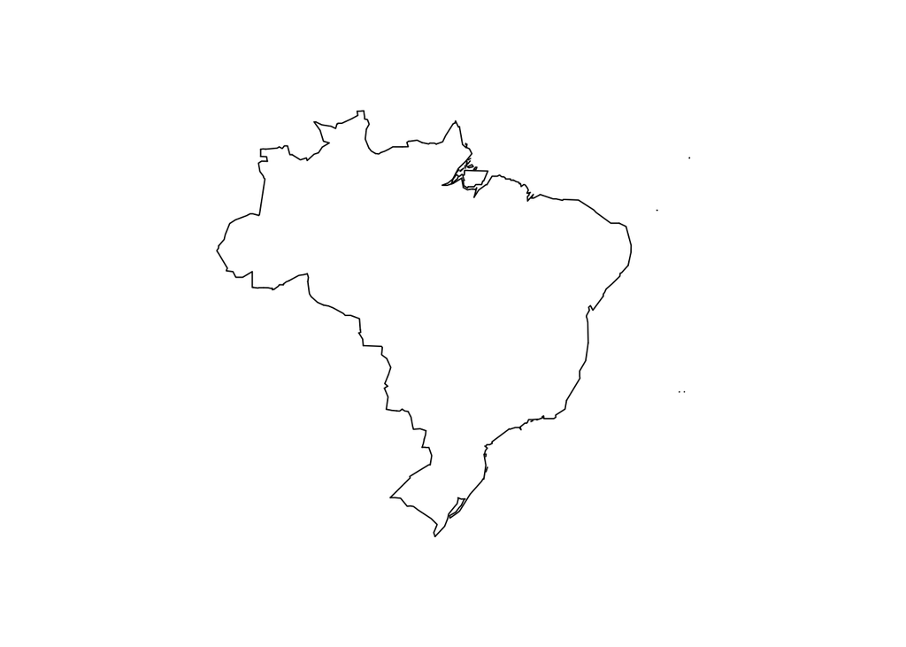

```r
# carregando pacotes
library(maps) # plotagem genérica de mapas
library(mapdata) # base de dados worldHires
# plotando o mapa do Brasil
map(database = "worldHires", regions = "Brazil")
```

Você pode adicionar a projeção dos outros países no espaço disponível:

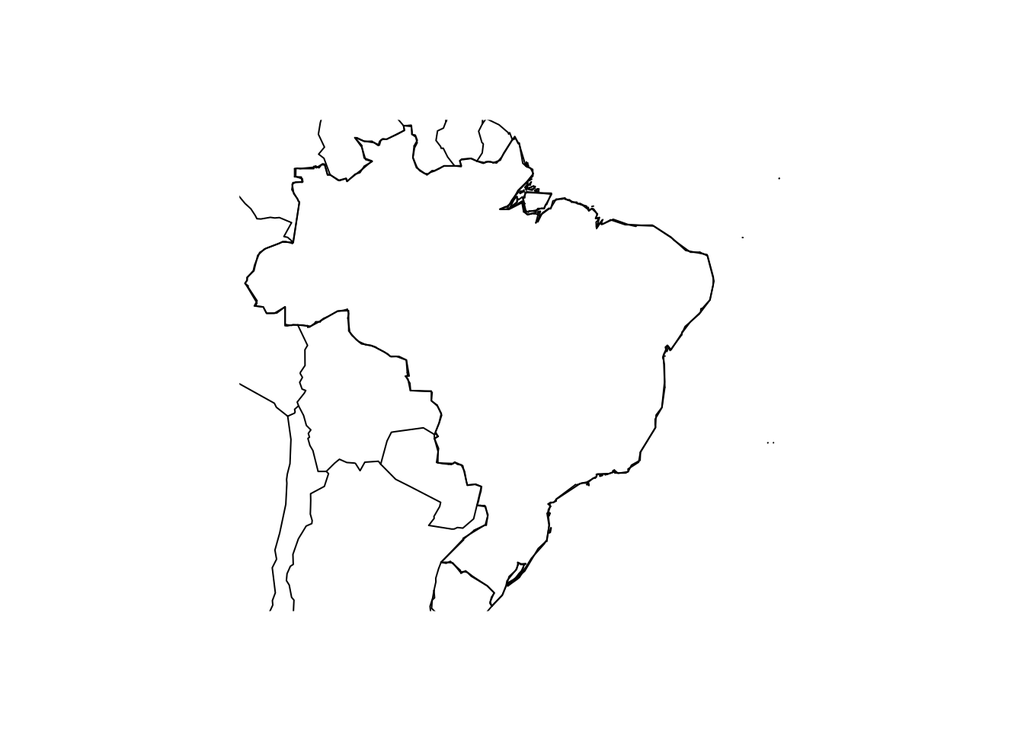

```r
map(database = "worldHires", regions = "Brazil")
map(add = TRUE)
```

Adicionando os eixos de longitude e latitude:

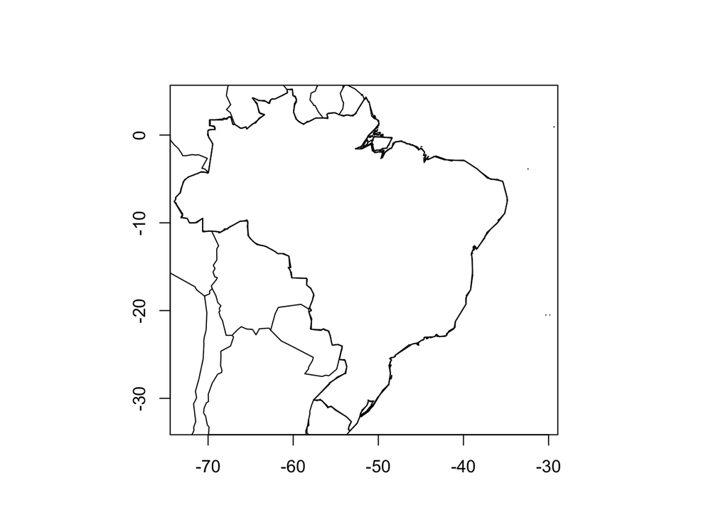

```r
map(database = "worldHires", regions = "Brazil")
map(add = TRUE)
map.axes()
```

Adicionando escala ao mapa e uma linha para representar o Equador:

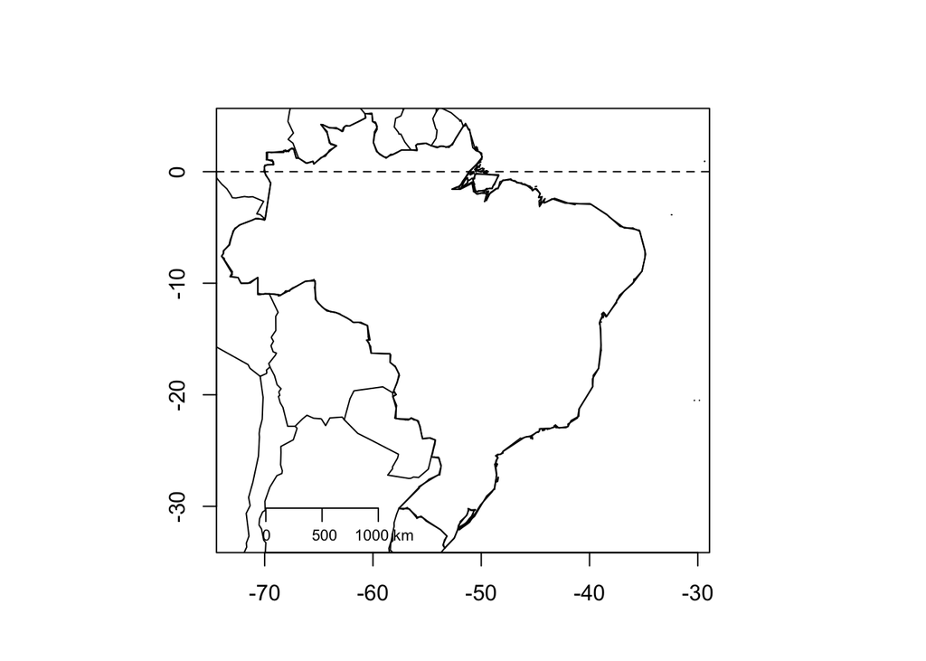

```r
map(database = "worldHires", regions = "Brazil")
map(add = TRUE)
map.axes()
map.scale(ratio = FALSE, cex = 0.7)
abline(h = 0, lty = 2)
```

Você também pode plotar os pontos correspondentes às cidades ao mapa usando a função:

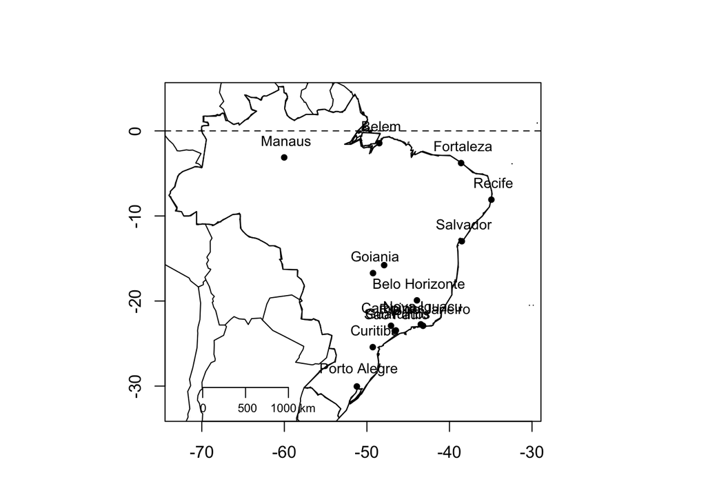

```r
map(database = "worldHires", regions = "Brazil")
map(add = TRUE)
map.axes()
map.scale(ratio = FALSE, cex = 0.7)
abline(h = 0, lty = 2)
map.cities(country = "Brazil", minpop = 1000000, pch = 19, cex = 1.2)
```

##### Exercício 1

Modifique as opções apresentadas anteriormente para explorar as opções gráficas disponíveis nas funções utilizadas.

Uma outra opção para criar mapas com base nos dados já existentes nos pacotes do R é através do `ggplot2`, através da função `borders`. A função `borders` (do `ggplot2`) funciona de forma similar àquela do pacote `maps`.

```r
# carregando o ggplot2
suppressPackageStartupMessages(library(ggplot2))
```

##### Exercício 2

Utilize a função `borders` do pacote `ggplot2` para criar um mapa editado do Brasil.